# BIOS226 — Topic 1

## Introduction to R

*R. Treharne*

## 1. Why are we using R in BIOS226?

We will be using lots of different tools in this module. But let’s start with R.

R is one of the most widely used tools in bioinformatics and computational biology.  
In this module, you will use R to:

- Load and explore biological datasets
- Visualise patterns and variation
- Perform statistical analyses
- Build and evaluate biological models

You are **not expected to be an expert programmer**.  
You *are* expected to develop confidence working with data in a reproducible way.

By the end of this workshop, you should be able to:

1. **Install and run R and RStudio** on your own computer and confirm that they are working correctly.
2. **Create and use an R Project** to organise files and manage data reproducibly.
3. **Write and run a basic R script**, understanding the difference between the console and a script file.
4. **Load a simple biological dataset into R** and inspect its structure using `head()`, `str()`, and `summary()`.
5. **Extract and summarise data from a dataset**, including calculating basic summary statistics.
6. **Produce a basic plot** to visualise relationships in biological data.
7. **Run a simple statistical model (ANOVA)** and explain, at a conceptual level, what question it is addressing.
8. **Explain why R will be used throughout BIOS226** and how the skills from this workshop will support later topics in the module.

These objectives map directly to the **Week 1 portfolio activity** and form the foundation for all subsequent workshops.

## 2. Installing R and RStudio

### What is R?

- R is the **language** used to analyse data.

### What is RStudio?

- RStudio is the **interface** that makes R easier to use.

You need **both**.

### Installation instructions

#### Windows

1. Install R from: https://cran.r-project.org
2. Install RStudio from: https://posit.co/download/rstudio-desktop/

#### macOS

1. Install R from: https://cran.r-project.org
2. Install RStudio from: https://posit.co/download/rstudio-desktop/

If RStudio opens and you see a **Console** window, installation was successful.

## 3. Creating an R Project (important)

We will always work inside **R Projects**.

### Why use projects?

- Keeps files organised
- Avoids broken file paths
- Improves reproducibility

### Create a project

1. `File` → `New Project`
2. `New Directory`
3. `New Project`
4. Name it `BIOS226_Week01`
5. Click **Create Project**

All files for this workshop should live inside this folder.

## 4. What is a script?

An R script is a plain text file that contains a sequence of R commands.  
Unlike typing commands directly into the Console, a script can be saved, re-run, shared, and submitted as part of your portfolio.

In BIOS226, scripts are how we make our work reproducible.

### Console vs Script

**Console**  
Commands typed here run immediately.  
This is useful for quick checks or experimenting.  
Commands typed into the Console are not saved automatically.

**Script**  
Commands are written in a file.  
Scripts can be run again later.  
Scripts are the main way you will work with and submit code in BIOS226.

### Creating your own script

Create a new script:

File → New File → R Script

Add the following at the top of the file:

```r
# BIOS226 Week 1
# Introduction to R
# Your Name
```

Save the file as:

`week01_intro_to_r.R`

We’ll be coming back to this script shortly. But first …

### Running the example data-generation script

I have pre-prepared an R script for you called

[`generate_example_data.R`](https://canvas.liverpool.ac.uk/courses/90784/files/13498583/download?download_frd=1)

Download it to you project **NOW!**. Make sure you don’t change the filename.

This script will:

- Generate a small, simulated biological dataset
- Use a student ID to ensure the data are reproducible (and unique for each of you)

You do not need to understand the contents of this script.  
Think of it as a tool that prepares the data you will use in the rest of this week’s workshops.

### Important: student ID for this resource

For this workshop resource, use the following student ID:

`123456789`

Using the same ID ensures that your dataset matches the examples shown later in this resource, so you can reproduce the figures and results demonstrated.

You will use your own student ID when completing the portfolio tasks for this workshop.

### Run the script in RStudio

- Open the file generate_example_data.R in RStudio.
- Click Source (top right of the script window).

When prompted, enter:

`123456789`

If successful, the file `example_bio_data.csv` will appear in your project folder. Does it?

### What happens next?

Now that `example_bio_data.csv` has been created in your project, you will proceed toload the data into R, explore its structure, visualise relationships in the data, and use it for a simple statistical analysis. How exciting!

## 5. Loading a dataset

In this section, you will load the dataset that you **have already generated yourself** using the script:

`generate_example_data.R`

If you ran that script successfully, a file called:

`example_bio_data.csv`

will already exist inside your **project folder**.  
You do **not** need to download anything from Canvas.

You should now return to work in your new, blank script file:

`week01_intro_to_r.R`

Open this file in RStudio (It’s probably still open). All of the code below should be added to this script (not typed directly into the Console).

### Step 1: Reading the data into R

Add the following line to your script:

```r
data <- read.csv("example_bio_data.csv")
```

### What is happening here?

- `read.csv()` is a **function** that reads data from a CSV file.
- `"example_bio_data.csv"` is the name of the file you want R to read.
- `data` is a **variable**.

A variable is a name that refers to an object stored in memory.  
After this line runs, the variable `data` will refer to the entire dataset.

You can choose different variable names, but `data` is short, clear, and commonly used.

### What does `<-` mean?

The symbol `<-` is the **assignment operator** in R.

It means:

Take the result on the right-hand side and store it in the variable on the left-hand side.

So this line:

```r
data <- read.csv("example_bio_data.csv")
```

should be understood to:

Read the file called `example_bio_data.csv` and store it in a variable called data.

You will see `<-` used constantly in R scripts throughout this module.

To run the line, click anywhere on the line and click the `Run` button in the top right

corner of your script window.

If all goes well, you should see an item called `data` in your *enrivonment* window in the top-right corner of your R-Studio.

## Click it! See what happens.

### Step 2: Inspecting the dataset

Once the data has been loaded, add and run the following lines to your script:

```r
head(data)
```

|  | sample_id | condition | temperature | growth_rate |
| --- | --- | --- | --- | --- |
| 1 | S1 | Control | 31.0 | 0.823 |
| 2 | S2 | Control | 30.8 | 0.663 |
| 3 | S3 | Control | 32.8 | 0.752 |
| 4 | S4 | Control | 28.6 | 0.871 |
| 5 | S5 | Control | 28.8 | 0.827 |
| 6 | S6 | Control | 26.9 | 0.783 |

```r
str(data)
```

```
## 'data.frame':    30 obs. of  4 variables:
##  $ sample_id  : chr  "S1" "S2" "S3" "S4" ...
##  $ condition  : chr  "Control" "Control" "Control" "Control" ...
##  $ temperature: num  31 30.8 32.8 28.6 28.8 26.9 30.3 29.7 27 32.3 ...
##  $ growth_rate: num  0.823 0.663 0.752 0.871 0.827 0.783 0.76 0.856 0.587 0.838 ...
```

```r
summary(data)
```

```
##   sample_id          condition          temperature     growth_rate
##  Length:30          Length:30          Min.   :26.10   Min.   :0.5870
##  Class :character   Class :character   1st Qu.:27.82   1st Qu.:0.8020
##  Mode  :character   Mode  :character   Median :29.55   Median :0.8705
##                                        Mean   :29.64   Mean   :0.8912
##                                        3rd Qu.:31.43   3rd Qu.:0.9868
##                                        Max.   :32.80   Max.   :1.1100
```

Run the script.

### What should you expect to see?

#### head(data)

This displays the **first six rows** of the dataset.

Use this to: - Confirm that the data loaded correctly - See the column names - Get an initial sense of what each column represents

You should see columns such as: - sample_id  
- condition  
- temperature  
- growth_rate

#### str(data)

This shows the **structure** of the dataset.

It tells you: - How many rows and columns the dataset has - The data type of each column (numeric, character, factor, etc.)

This is especially important in bioinformatics, because many analyses require variables to be the correct type.

For example: - `condition` should be a factor (although right now it is `Char`) - `temperature` and `growth_rate` should be numeric

#### summary(data)

This produces summary statistics for each column.

This gives you a quick overview of the entire dataset.

### Step 3: Summary statistics by group

In biology, we often want to summarise measurements **by experimental group**.

To generate summary statistics for growth rate separately for each condition, add and run the following line to your script:

```r
tapply(data$growth_rate, data$condition, summary)
```

```
## $Control
##    Min. 1st Qu.  Median    Mean 3rd Qu.    Max.
##  0.5870  0.7705  0.8000  0.7917  0.8355  0.9190
##
## $Treatment
##    Min. 1st Qu.  Median    Mean 3rd Qu.    Max.
##  0.8080  0.9450  0.9950  0.9908  1.0465  1.1100
```

### What does this do?

- `data$growth_rate` selects the growth rate column
- `data$condition` defines the grouping variable
- `summary` is applied separately to each group

The output is a grouped table of summary statistics, allowing you to compare conditions directly.

This type of grouped summary is a foundation for: - Data visualisation - Statistical testing - Biological interpretation

### What if you want to save the grouped summary as a CSV file?

Sometimes you may want to save results to a file so they can be reused later, included in a report, or shared with others.

First, store the grouped summary in a variable:

```r
grouped_summary <- tapply(data$growth_rate, data$condition, summary)
```

The object created by `tapply()` is a list. To save it as a CSV file, we first convert it into a data frame:

```r
grouped_summary_df <- do.call(rbind, grouped_summary)
```

Now write it to a CSV file:

```r
write.csv(grouped_summary_df, "grouped_growth_rate_summary.csv")
```

This will create a file called:

`grouped_growth_rate_summary.csv`

in your project folder. This is great! It means that you can open the file up in Excel and then copy and paste into a report if you want.

## 6. Working with columns

Once a dataset has been loaded into R, we often want to work with **individual columns** rather than the whole table.

The object `data` is a **data frame**, meaning: - each column is a variable - each row is an observation

### Selecting a column

To access a single column, use the `$` operator:

```r
data$growth_rate
```

This tells R to:

- look inside the object called data
- extract the column named growth_rate

The result is a numeric vector containing all growth rate values.

Most statistical functions in R work on vectors, not entire data frames, which is why this step is important.

### Calculating a mean

To calculate the average growth rate across all samples:

```r
mean(data$growth_rate)
```

```
## [1] 0.8912333
```

What happens here:

- data$growth_rate selects the values in the column `growth_rate`
- mean() calculates the arithmetic average
- R returns a single number

This value represents the mean growth rate across all conditions combined.

### Storing results (optional)

If you want to reuse the result later, you can store it in a variable:

```r
overall_mean_growth <- mean(data$growth_rate)
```

Typing the variable name will display the stored value. Try it!

## 7. Basic visualisation

Visualisation is one of the most important steps in data analysis.  
Before running statistical tests or models, we should **look at the data**.

Plots help us to:

- understand patterns and trends
- compare experimental groups
- identify variability and potential outliers

### Response variables and independent variables

In most biological experiments, we distinguish between two types of variables:

- **Response variable**  
  This is the outcome you measure.  
  In this dataset, the response variable is:

  `growth_rate`
- **Independent variable**  
  This is a variable that may influence the response.  
  In this dataset, independent variables include:

  `condition` `temperature`

When we make plots, we usually place:

- the **independent variable** on the x-axis
- the **response variable** on the y-axis

### Plot 1: Grouped boxplot (growth rate by treatment)

A boxplot is useful for comparing a response variable across discrete groups.

To create a boxplot of growth rate for each treatment condition, add and run:

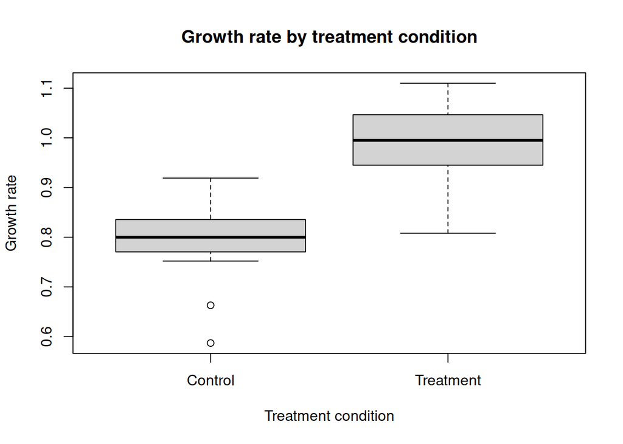

```r
boxplot(growth_rate ~ condition,
        data = data,
        xlab = "Treatment condition",
        ylab = "Growth rate",
        main = "Growth rate by treatment condition")
```

What this plot shows:

- one box per treatment group
- the median growth rate in each group
- the spread and variability within each group
- potential outliers

This plot is especially useful when preparing for statistical tests such as ANOVA (See section 8).

### Plot 2: Scatterplot (temperature vs growth rate)

A scatterplot is used to explore the relationship between two **continuous variables**.

To plot temperature against growth rate, add and run:

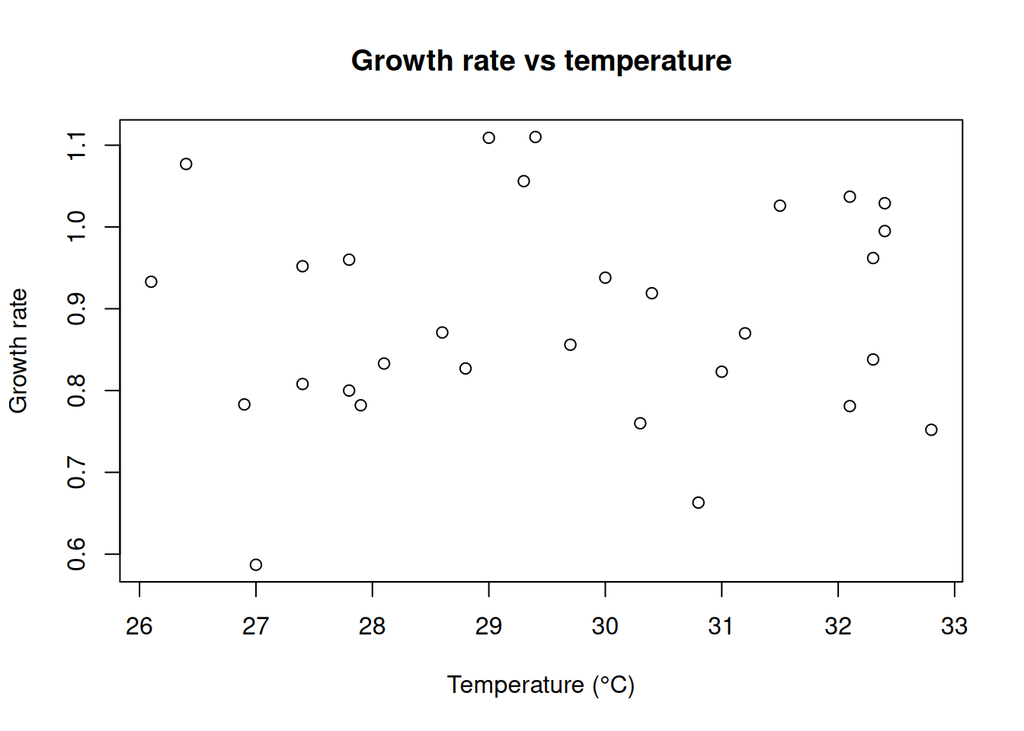

```r
plot(data$temperature,
     data$growth_rate,
     xlab = "Temperature (°C)",
     ylab = "Growth rate",
     main = "Growth rate vs temperature")
```

In this plot:

- temperature is the independent variable (x-axis)
- growth rate is the response variable (y-axis)
- each point represents a single sample

Scatterplots help you assess whether changes in an independent variable are associated with changes in the response variable.

### Why these plots matter

Together, these two plots allow you to:

- compare growth rate across treatment groups
- explore how growth rate varies with temperature
- develop intuition before formal statistical analysis

Visualisation is not optional — it is a core part of good biological data analysis.

## 8. A first statistical model: ANOVA

In this section, you will run your **first formal statistical model** in BIOS226.

The goal here is **not** to master statistics.  
It is to understand **what question the model is asking**, **what the output means**, and **why we use it**.

### What is ANOVA?

ANOVA stands for **Analysis of Variance**.

It is used when you want to test whether the **mean value of a response variable** differs between **two or more groups**.

In our experiment:

ANOVA answers the question:

Are the differences in mean growth rate between treatment groups larger than we would expect by chance alone?

### Running the ANOVA

Add the following lines to your script and run them:

```r
anova_model <- aov(growth_rate ~ condition, data = data)
summary(anova_model)
```

```
##             Df Sum Sq Mean Sq F value   Pr(>F)
## condition    1 0.2974 0.29741   42.44 4.64e-07 ***
## Residuals   28 0.1962 0.00701
## ---
## Signif. codes:  0 '***' 0.001 '**' 0.01 '*' 0.05 '.' 0.1 ' ' 1
```

### What does this code do?

- `aov()` fits an ANOVA model
- `growth_rate ~ condition` specifies the model structure
- `data = data` tells R where to find the variables
- `anova_model` stores the fitted model
- `summary(anova_model)` displays the results

###Interpreting the output

Let’s take a look at the ANOVA result output above:

- Each row represents a source of variation
- Each column contains a different piece of statistical information

The most important row for interpretation is the one labelled:

`condition`

Understanding the columns

- **Df (Degrees of Freedom)** This reflects how many independent pieces of information are used to estimate variation.

  For condition, this is the number of groups minus one

  For Residuals, this reflects the remaining unexplained variation
- **Sum Sq (Sum of Squares)** This measures how much variation is associated with each source.

  The larger the value, the more variation is attributed to that source
- **Mean Sq (Mean Square)** This is the sum of squares divided by the degrees of freedom.

  It represents the average variation per degree of freedom
- **F value** This is the test statistic for ANOVA.

  It compares the variation between groups to the variation within groups

  Large F values indicate that group means differ more than would be expected by chance
- **Pr(>F) (p-value)** This is the probability of observing an F value this large if there were actually no differences between group means.

  Interpreting this specific result

In this output:

This provides very strong evidence that mean growth rate differs between at least some of the treatment groups.

The *** symbols are significance codes added by R to indicate very small p-values. They are a visual aid only and do not change the interpretation.

### What if the ANOVA is significant?

If the ANOVA result is statistically significant, the next step is to perform **post-hoc tests**.

Post-hoc tests allow you to:

- Compare groups pairwise
- Identify which specific treatments differ from each other

You will encounter these ideas in more detail elsewhere in your degree.

For now, remember: ANOVA is a starting point, not the end of the analysis.

### What about assumptions?

Like all statistical tests, ANOVA relies on assumptions, including:

- Independence of observations
- Normally distributed residuals
- Similar variance across groups

You will cover these assumptions formally in **BIOS203**.

For this workshop:

- Do not worry about checking assumptions yet
- Focus on understanding what the model is doing conceptually

### Why are we doing this now?

ANOVA introduces several ideas that will appear repeatedly in BIOS226:

- Modelling biological data
- Comparing experimental groups
- Interpreting statistical output
- Deciding what to do next in an analysis

Later in the module, these same ideas will extend to:

- More complex models
- High-dimensional data
- Supervised learning and model evaluation

This is your first step into statistical modelling.

## 9. Getting Ready for Week 2: Installing and loading R packages

Well done on completing this week’s workshop. You should now be back up to speed with your RStudio environment.

There’s one last thing that I want to discuss and that is R packages.

R packages extend what R can do and typically You only need to **install** a package once per computer, but you must **load** it every time you start R.

⚠️ **Important:**  
If you change computers or reinstall R, you will need to install packages again.

### Installing Biostrings (Bioconductor)

**Biostrings** is a bioinformatics package from **Bioconductor**, a specialised collection of R packages for analysing biological data such as DNA, RNA, and protein sequences. Biostrings provides tools for storing, manipulating, and analysing biological sequences in a way that is efficient and biologically meaningful.

You will use Biostrings in next week’s workshop to work directly with sequence data, so we will install it now to make sure everyone’s system is ready.

Add the following code to your script and run it line by line:

```r
if (!requireNamespace("BiocManager", quietly = TRUE)) {
  install.packages("BiocManager")
}

BiocManager::install("Biostrings")
```

This step may take a few minutes and will generate a lot of Console output — this is normal.

### Loading the package

Once installed, load the package using:

```r
library(Biostrings)
```

If this runs without errors, Biostrings is ready to use. If you get errors then don’t panic, we can help you fix during the workshop.

You must include `library(Biostrings)` near the top of your script whenever you want to use the package.

Try adding and running the following line to your script. Are you able to reproduce the output?

```r
alphabetFrequency(DNAString("ACGTACGT"))
```

```
## A C G T M R W S Y K V H D B N - + .
## 2 2 2 2 0 0 0 0 0 0 0 0 0 0 0 0 0 0
```

## Summary

After working through this resource, you should now be able to:

- Explain why R is used in bioinformatics and computational biology
- Work within an R Project and use scripts rather than the Console
- Generate a reproducible dataset using a script
- Load data into R and inspect its structure
- Work with individual variables (columns)
- Visualise data using appropriate plots
- Run and interpret a simple statistical model (ANOVA) at a conceptual level
- Install Biostring and run a simple script that uses the package.